# Meteorite Report

```r
# load in the tidyverse and maps packages.
library(tidyverse)
library(maps)
```

```r
# read in the clean data

meteorites <- read_csv("data/clean_meteorites_data.csv")
```

```r
dim(meteorites)
```

```
## [1] 4823    7
```

The top of the data, showing the column names and some of the data.

```r
head(meteorites)
```

| id | name | mass | fall | year | latitude | longitude |
| --- | --- | --- | --- | --- | --- | --- |
| 5295 | Castrovillari | 15000 | Fell | 1583 | 39.80000 | 16.20000 |
| 16745 | Morito | 10100000 | Found | 1600 | 27.05000 | -105.43333 |
| 12069 | Jalandhar | 1967 | Fell | 1621 | 31.00000 | 75.00000 |
| 23732 | Stretchleigh | 10400 | Fell | 1623 | 50.38333 | -3.95000 |
| 11855 | Hatford | 29000 | Fell | 1628 | 51.65000 | -1.51667 |
| 16692 | Minamino | 1040 | Fell | 1632 | 35.07833 | 136.93333 |

Note: meteorite data only available to 2013.

The names and years found for the ten largest meteorites:

```r
largest_meteorites <- meteorites %>%
  # select only necessary columns
  select(Name = name, `Mass (kg)` = mass, Year = year) %>%
  slice_max(`Mass (kg)`, n = 10)

library(huxtable)
ht <- largest_meteorites %>%
  as_huxtable()

bold(ht)[1,]           <- TRUE
bottom_border(ht)[1,]  <- 0.4
align(ht)[,2]          <- 'right'
right_padding(ht)      <- 10
left_padding(ht)       <- 10
width(ht)              <- 0.35
number_format(ht)      <- 0

ht
```

| Name | Mass (kg) | Year |
| --- | --- | --- |
| Hoba | 60000000 | 1920 |
| Cape York | 58200000 | 1818 |
| Campo del Cielo | 50000000 |  |
| Canyon Diablo | 30000000 | 1891 |
| Armanty | 28000000 | 1898 |
| Gibeon | 26000000 | 1836 |
| Chupaderos | 24300000 | 1852 |
| Mundrabilla | 24000000 | 1911 |
| Sikhote-Alin | 23000000 | 1947 |
| Bacubirito | 22000000 | 1863 |

```r
library(ggplot2)
```

According to the wikipedia entry for Campo del Cielo it was “found” < 1576. This may be why it is recorded as NA in the year table.

The average mass of meteorites that were recorded falling, vs. those which were just found.

```r
falling_meteorites <- meteorites %>%
  filter(fall == "Fell")

avg_mass_falling_meteorites <- falling_meteorites %>%
  summarise(avg_mass = mean(mass, na.rm = TRUE)) %>%
  pull()

avg_mass_falling_meteorites/1000
```

```
## [1] 69.50995
```

Almost 70kg

How does this compare with meteorites that were just found?

[output not shown]

The number of meteorites in each year, for every year since 2000.

[output not shown]

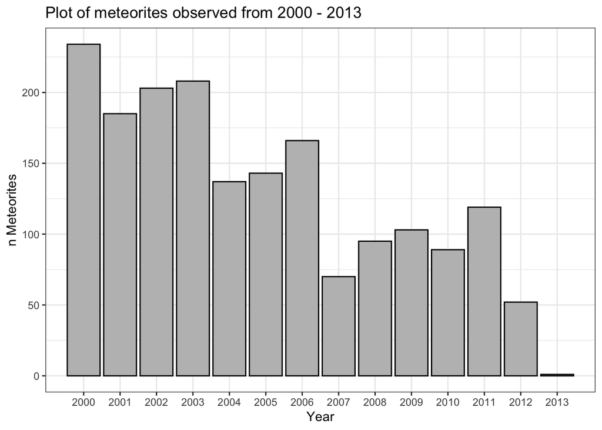

```r
count_meteorites %>%
  ggplot() +
    geom_col(
             aes(x = year, y = n_meteorites),
             colour = "black", fill = "grey") +
    scale_x_discrete(breaks = seq(2000, 2013),
                     limits = seq(2000, 2013)) +
    labs(x = "Year",
         y = "n Meteorites",
         title = "Plot of meteorites observed from 2000 - 2013") +
    theme_bw()
```

The trend is that over time, less meteorites are recorded per year.

What is trend in meteorites observed to have fallen in the same period?

```r
count_fell_meteorites <- recent_meteorites %>%
  filter(fall == "Fell") %>%
  add_count(year) %>%
  group_by(year) %>%
  summarise("n_fell_meteorites" = mean(n), .groups = 'drop')

count_fell_meteorites
```

| year | n_fell_meteorites |
| --- | --- |
| 2e+03 | 2 |
| 2e+03 | 4 |
| 2e+03 | 5 |
| 2e+03 | 6 |
| 2e+03 | 4 |
| 2.01e+03 | 4 |
| 2.01e+03 | 3 |
| 2.01e+03 | 8 |
| 2.01e+03 | 3 |
| 2.01e+03 | 4 |
| 2.01e+03 | 4 |
| 2.01e+03 | 1 |
| 2.01e+03 | 1 |

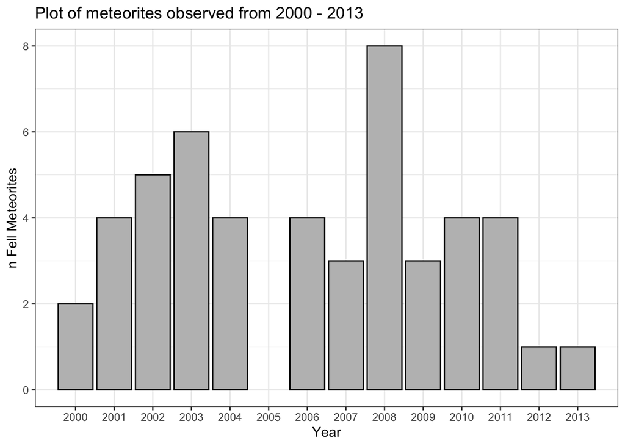

```r
count_fell_meteorites %>%
  ggplot() +
    geom_col(
             aes(x = year, y = n_fell_meteorites),
             colour = "black", fill= "grey") +
    scale_x_discrete(breaks = seq(2000,2013),
                     limits = seq(2000,2013)) +
    labs(x = "Year",
         y = "n Fell Meteorites",
         title = "Plot of meteorites observed from 2000 - 2013") +
    theme_bw()
```

While the number of meteorites per year has decreased over time, the number of meteorites observed falling has not, but has remained consistently low. The implication then is that we are finding old meteorites faster than new ones are falling.

The data includes lat/long co-ordinates. Plot every meteorite on a map of the world, placed where it was found.

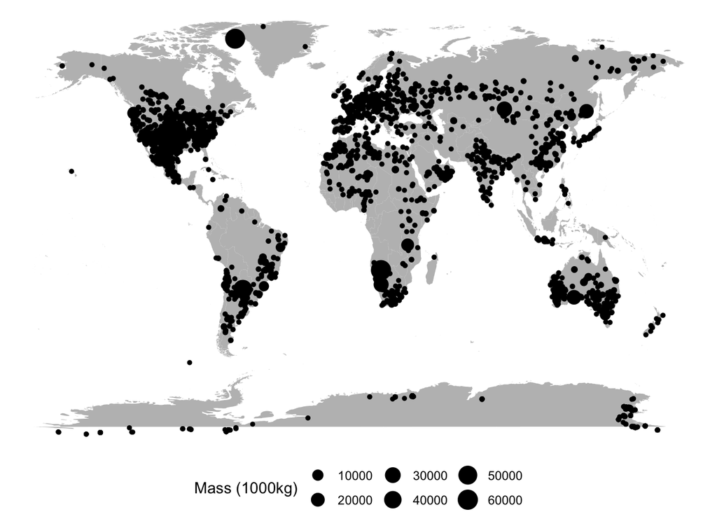

```r
# load in world map
earth_map <- map_data("world")

# remove the missing values from the plot
meteorites <- meteorites %>%
  filter(latitude!=0 & longitude !=0)

ggplot() +
  # continental grey background
  geom_polygon(data = earth_map, aes(x = long, y = lat, group = group),
               fill = "grey", alpha = 1.5) +
  # plot lat/longs on top
  geom_point(data = meteorites %>% mutate(mass = mass/1000),
             aes(x = longitude, y = latitude, size = mass)) +
  coord_cartesian() +
  theme_classic() +
  theme_void() +
  labs(size = "Mass (1000kg)") +
  theme(legend.position = "bottom", plot.title = element_text(hjust = 0.5)) +
  guides(size = guide_legend(nrow = 2))
```

Plot only the largest (greatest mass) meteorites on the world map.

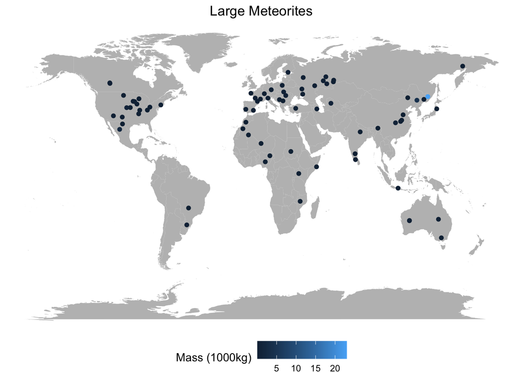

```r
large_meteorites <- falling_meteorites %>%
  # the selection of large meteorites will be those greater than the avg mass
  filter(mass > avg_mass_falling_meteorites) %>%
  # change the units of mass from grams to something more sensible for the plot
  mutate(mass = mass/1000/1000)


ggplot() +
  # plot map
  geom_polygon(data = earth_map, aes(x = long, y = lat, group = group),
               fill = "grey", alpha = 1.5) +
  # plot data
  geom_point(data = large_meteorites,
             aes(x = longitude, y = latitude, color = mass)) +
  coord_cartesian() +
  labs(color = "Mass (1000kg)", title = "Large Meteorites") +
  theme_void() +
  theme(legend.position = "bottom", plot.title = element_text(hjust = 0.5)) +
  guides(size = guide_legend(nrow = 2))
```

From the plot very few meteorites exist in the largest mass category. Most are < 5*1000kg. It may be that a few very very large meteorites drag the mean average up. How does the median average of falling meteorites compare.

```r
median_avg_mass <- falling_meteorites %>%
  summarise(avg_mass = median(mass, na.rm = TRUE)) %>%
  pull()

median_avg_mass/1000
```

```
## [1] 6
```

6kg. It is less than 1/10th of what the mean is. The implication, then ,is that the majority of meteorites are considerably less than the mean average mass.

Plot the meteorites found falling in the last 100 years.

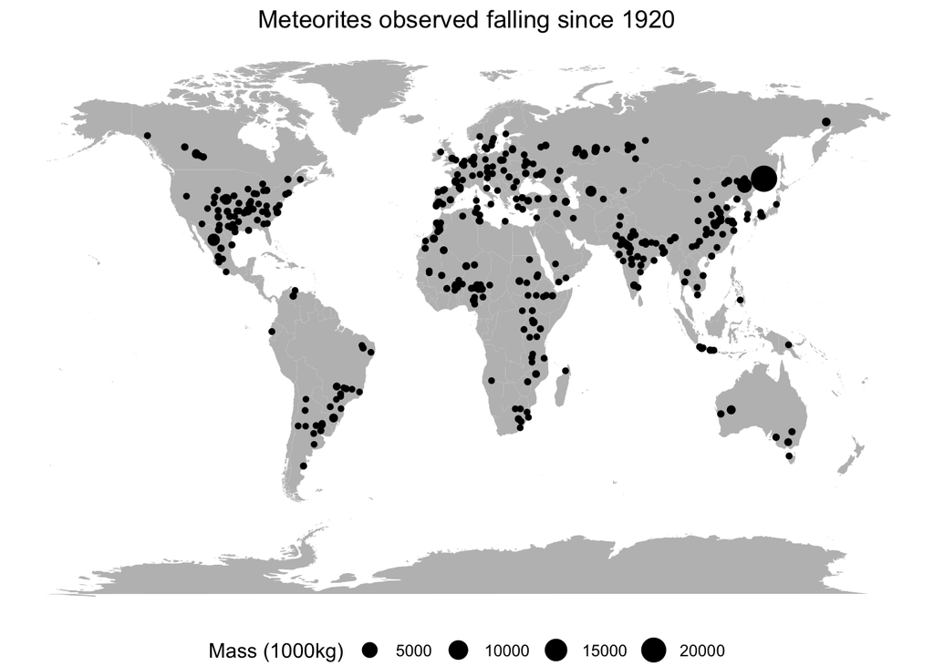

```r
meteorites_last_100_years <- falling_meteorites %>%
  filter(year > 1920) %>%
  # remove the missing values
  filter(latitude != 0 & longitude != 0)

ggplot() +
  geom_polygon(data = earth_map, aes(x = long, y = lat, group = group),
               fill = "grey", alpha = 1.5) +
  geom_point(data = meteorites_last_100_years,
             aes(x = longitude, y = latitude, size = mass/1000)) +
  coord_cartesian() +
  labs(title = "Meteorites observed falling since 1920", size = "Mass (1000kg)") +
  theme_void() +
  theme(legend.position = "bottom",  plot.title = element_text(hjust = 0.5)) +
  guides(size = guide_legend(nrow = 1))
```

Plot the meteorites observed falling in the past 40 years. Distinguish decade by colour.

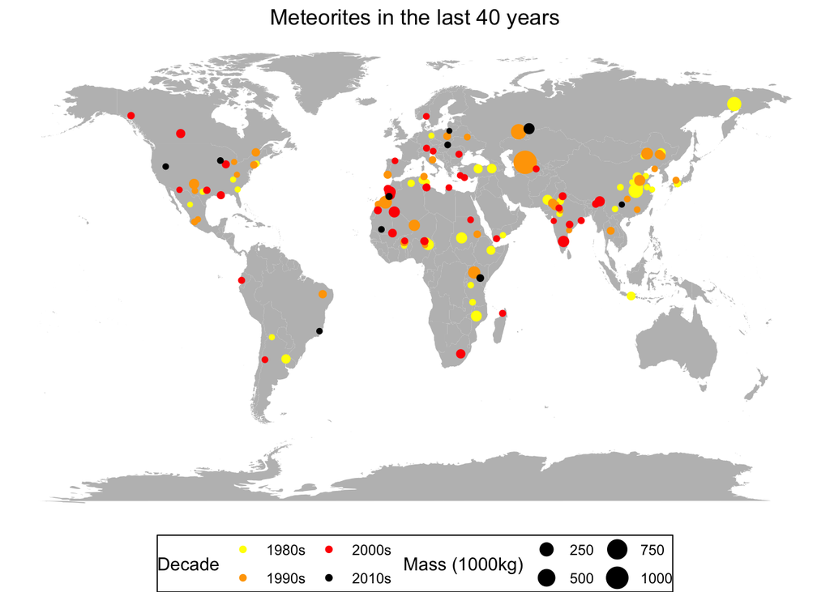

```r
recent_meteorites <- meteorites_last_100_years %>%
  filter(year >= 1980) %>%
  mutate(decade = case_when(
    year >= 1980 & year < 1990 ~ "1980s",
    year >= 1990 & year < 2000 ~ "1990s",
    year >= 2000 & year < 2010 ~ "2000s",
    year >= 2010 & year < 2020 ~ "2010s"
  )) %>%
  group_by(decade)

ggplot() +
  geom_polygon(data = earth_map,
               aes(x = long, y = lat, group = group),
               fill = "grey", alpha = 1.5) +
  geom_point(data = recent_meteorites,
             aes(x = longitude, y = latitude,
                 colour = decade, size = mass/1000)) +
  scale_color_manual(values = c("1980s" = "yellow",
                                "1990s" = "orange",
                                "2000s" = "red",
                                "2010s" = "black")) +
  labs(color = "Decade",
       size = "Mass (1000kg)",
       title = "Meteorites in the last 40 years") +
  coord_cartesian() +
  theme_void() +
  theme(legend.position = "bottom", plot.title = element_text(hjust = 0.5),
        legend.box.background = element_rect()) +
  guides(size = guide_legend(nrow = 2, ncol = 2),
         colour = guide_legend(nrow = 2, ncol = 2))
```

Note, meteorite data only available to 2013.